# Practical Maching Learning Weight Lifting Exercise Prediction

Paul Bulson

Saturday, January 24, 2015

With thanks to Groupware@LES for providing the dataset http://groupware.les.inf.puc-rio.br/har and http://www.stackoverflow.com for R assistance.

# Executive Summary

The goal was using motion data captured from six paricipants performing a series of exercises, to develop a prediction model that accepts the motion data and predicts the exercise performed. After building three models, a random forest model achieved over 99% accuracy. The out of sample error rate was 0.578%.

# Data Processing

The initial step was to read the data and split into a train and test datasets. To build the model, use the training dataset. To estimate the out of sample error using cross-validation, feed the resulting model the testing dataset and analyze the results.

```r
library(caret)
library(rattle)
```

```r
library(reshape2)
library(ggplot2)
data <- read.csv("pml-training.csv")

# Split data into Training and Testing
set.seed(81115)
inTrain <- createDataPartition(y=data$classe, p=.7, list=FALSE)
training <- data[inTrain,]
testing <- data[-inTrain,]
```

# Feature Selection

As part of the process of selecting the appropriate predictors, eliminate the noise columns, those columns largely devoid of value, and those columns with near zero variance.

```r
# drop noise column
training <- training[,-(1:7), drop=FALSE]

# remove columns with too many missing values
predictorMissingValueCount <- sapply(training, function (x) sum(is.na(x) | x == ""))
training <- training[,predictorMissingValueCount<100]

# remove 0 covariates
nearZeroVar(training, saveMetrics=TRUE)
```

```
##                      freqRatio percentUnique zeroVar   nzv
## roll_belt             1.135266    8.06580767   FALSE FALSE
## pitch_belt            1.121429   12.22246488   FALSE FALSE
## yaw_belt              1.010753   12.76115600   FALSE FALSE
## total_accel_belt      1.051353    0.21110868   FALSE FALSE
## gyros_belt_x          1.074502    0.91723084   FALSE FALSE
## gyros_belt_y          1.132444    0.47317464   FALSE FALSE
## gyros_belt_z          1.045310    1.17201718   FALSE FALSE
## accel_belt_x          1.042672    1.15017835   FALSE FALSE
## accel_belt_y          1.072529    0.99730654   FALSE FALSE
## accel_belt_z          1.091057    2.06740919   FALSE FALSE
## magnet_belt_x         1.115226    2.22756060   FALSE FALSE
## magnet_belt_y         1.138702    2.07468880   FALSE FALSE
## magnet_belt_z         1.055901    3.15207105   FALSE FALSE
## roll_arm             55.162791   17.66033341   FALSE FALSE
## pitch_arm            81.827586   20.25915411   FALSE FALSE
## yaw_arm              28.926829   19.15993303   FALSE FALSE
## total_accel_arm       1.058544    0.48045425   FALSE FALSE
## gyros_arm_x           1.030812    4.57159496   FALSE FALSE
## gyros_arm_y           1.438017    2.67889641   FALSE FALSE
## gyros_arm_z           1.072776    1.68158987   FALSE FALSE
## accel_arm_x           1.008547    5.59074034   FALSE FALSE
## accel_arm_y           1.070064    3.81451554   FALSE FALSE
## accel_arm_z           1.000000    5.58346073   FALSE FALSE
## magnet_arm_x          1.067797    9.66732183   FALSE FALSE
## magnet_arm_y          1.092308    6.21678678   FALSE FALSE
## magnet_arm_z          1.070423    9.09223266   FALSE FALSE
## roll_dumbbell         1.061856   86.60551794   FALSE FALSE
## pitch_dumbbell        2.145631   84.29788163   FALSE FALSE
## yaw_dumbbell          1.107527   85.85571813   FALSE FALSE
## total_accel_dumbbell  1.067016    0.31302322   FALSE FALSE
## gyros_dumbbell_x      1.013889    1.68158987   FALSE FALSE
## gyros_dumbbell_y      1.261307    1.96549465   FALSE FALSE
## gyros_dumbbell_z      1.072464    1.41224430   FALSE FALSE
## accel_dumbbell_x      1.030303    2.97736041   FALSE FALSE
## accel_dumbbell_y      1.052023    3.29766325   FALSE FALSE
## accel_dumbbell_z      1.186747    2.93368275   FALSE FALSE
## magnet_dumbbell_x     1.233333    7.74550484   FALSE FALSE
## magnet_dumbbell_y     1.266667    6.01295771   FALSE FALSE
## magnet_dumbbell_z     1.029412    4.87733857   FALSE FALSE
## roll_forearm         11.483333   13.73662372   FALSE FALSE
## pitch_forearm        64.093023   19.07257771   FALSE FALSE
## yaw_forearm          15.653409   12.76115600   FALSE FALSE
## total_accel_forearm   1.107551    0.50957269   FALSE FALSE
## gyros_forearm_x       1.055402    2.06012958   FALSE FALSE
## gyros_forearm_y       1.007168    5.28499672   FALSE FALSE
## gyros_forearm_z       1.071225    2.11108685   FALSE FALSE
## accel_forearm_x       1.112903    5.64169761   FALSE FALSE
## accel_forearm_y       1.054054    7.05394191   FALSE FALSE
## accel_forearm_z       1.018018    4.06202228   FALSE FALSE
## magnet_forearm_x      1.137931   10.58455267   FALSE FALSE
## magnet_forearm_y      1.206897   13.28528791   FALSE FALSE
## magnet_forearm_z      1.000000   11.73473102   FALSE FALSE
## classe                1.469526    0.03639805   FALSE FALSE
```

# Exploratory data analysis

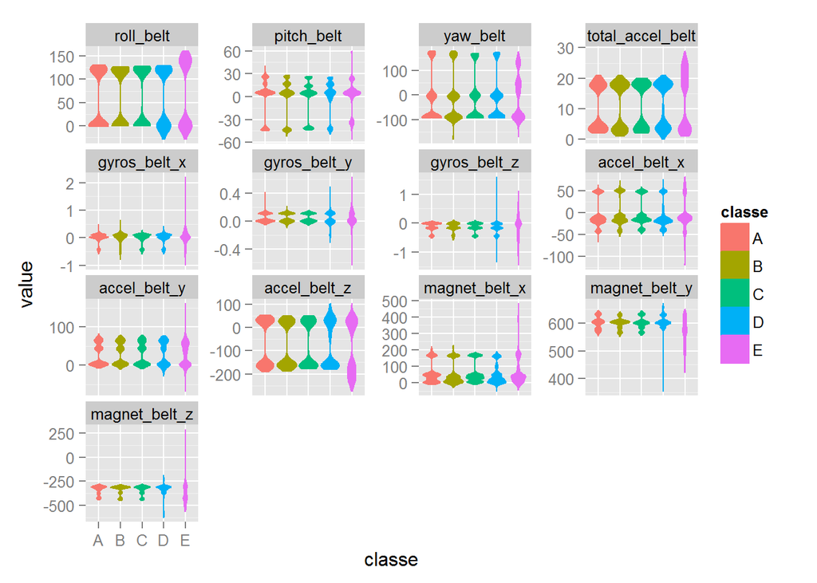

```r
# exploratory data analysis (thank you stackflow community for assistance with violin plots)
columns <- c(grep("belt", names(training)), which(names(training) == "classe"))
meltedData <- melt(training[, columns], id="classe")
ggplot(meltedData, aes(x=classe, y=value)) +
        geom_violin(aes(color=classe, fill=classe)) +
        facet_wrap(~ variable, scales="free_y")
```

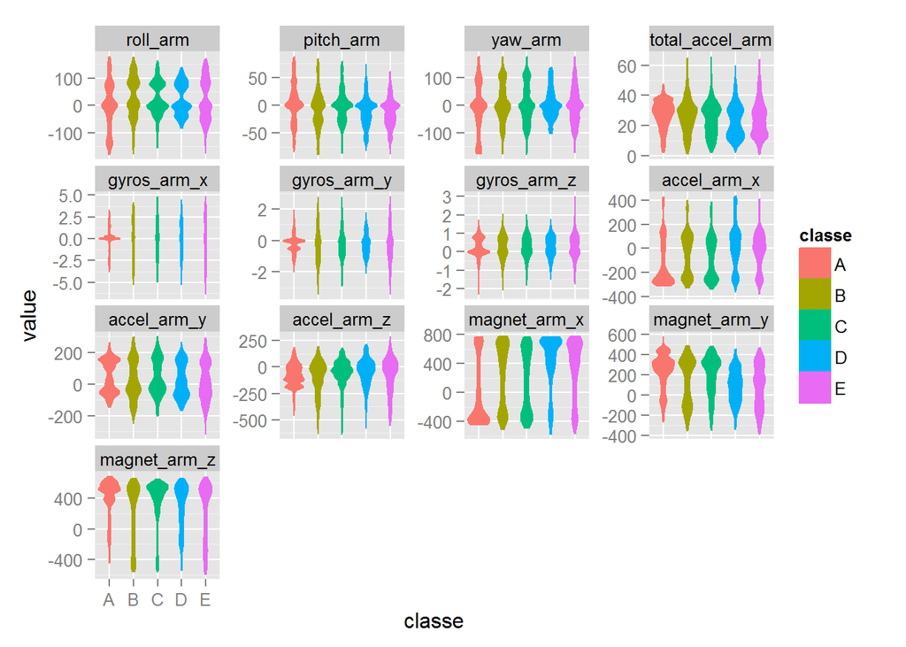

```r
columns <- c(grep("_arm", names(training)), which(names(training) == "classe"))
meltedData <- melt(training[, columns], id="classe")
ggplot(meltedData, aes(x=classe, y=value)) +
        geom_violin(aes(color=classe, fill=classe)) +
        facet_wrap(~ variable, scales="free_y")
```

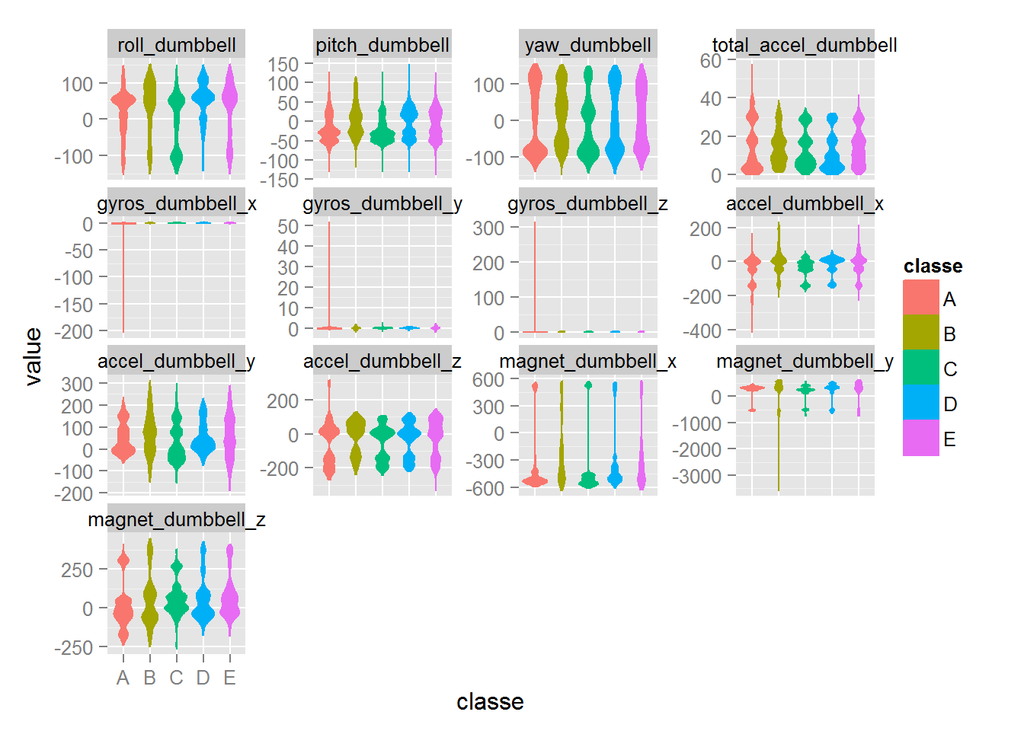

```r
columns <- c(grep("dumbbell", names(training)), which(names(training) == "classe"))
meltedData <- melt(training[, columns], id="classe")
ggplot(meltedData, aes(x=classe, y=value)) +
        geom_violin(aes(color=classe, fill=classe)) +
        facet_wrap(~ variable, scales="free_y")
```

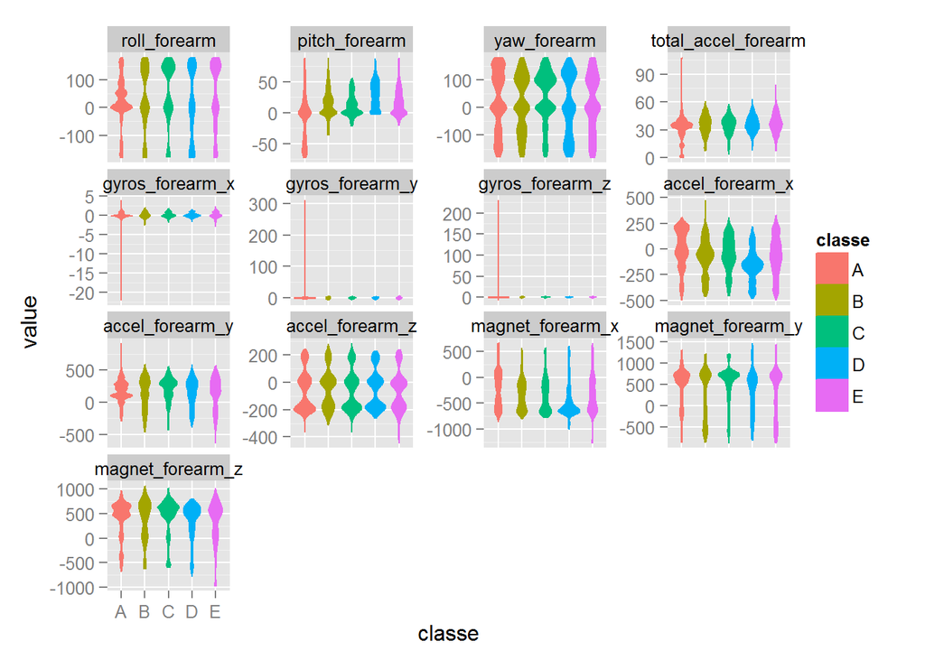

```r
columns <- c(grep("forearm", names(training)), which(names(training) == "classe"))
meltedData <- melt(training[, columns], id="classe")
ggplot(meltedData, aes(x=classe, y=value)) +
        geom_violin(aes(color=classe, fill=classe)) +
        facet_wrap(~ variable, scales="free_y")
```

# Build a tree model

```r
# trees
modelFitTrees <- train(classe ~ .,data=training, method="rpart")
print(modelFitTrees)
```

```
## CART
##
## 13737 samples
##    52 predictor
##     5 classes: 'A', 'B', 'C', 'D', 'E'
##
## No pre-processing
## Resampling: Bootstrapped (25 reps)
##
## Summary of sample sizes: 13737, 13737, 13737, 13737, 13737, 13737, ...
##
## Resampling results across tuning parameters:
##
##   cp      Accuracy  Kappa   Accuracy SD  Kappa SD
##   0.0339  0.517     0.3744  0.0310       0.0476
##   0.0592  0.405     0.1916  0.0593       0.0995
##   0.1157  0.346     0.0945  0.0352       0.0543
##
## Accuracy was used to select the optimal model using  the largest value.
## The final value used for the model was cp = 0.03387244.
```

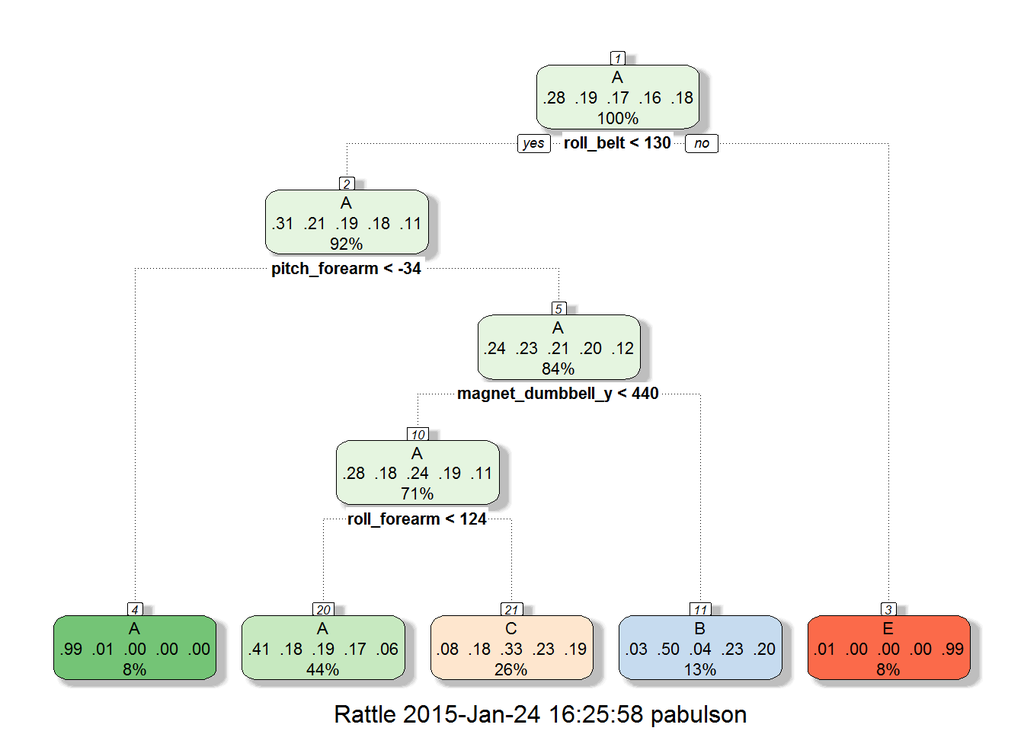

```r
fancyRpartPlot(modelFitTrees$finalModel)
```

```r
pred <- predict(modelFitTrees, newdata=testing)
confusionMatrixTrees <- confusionMatrix(pred,testing$classe)
confusionMatrixTrees
```

```
## Confusion Matrix and Statistics
##
##           Reference
## Prediction    A    B    C    D    E
##          A 1526  463  453  427  174
##          B   26  388   37  161  135
##          C  117  288  536  376  288
##          D    0    0    0    0    0
##          E    5    0    0    0  485
##
## Overall Statistics
##
##                Accuracy : 0.4987
##                  95% CI : (0.4859, 0.5116)
##     No Information Rate : 0.2845
##     P-Value [Acc > NIR] : < 2.2e-16
##
##                   Kappa : 0.3452
##  Mcnemar's Test P-Value : NA
##
## Statistics by Class:
##
##                      Class: A Class: B Class: C Class: D Class: E
## Sensitivity            0.9116  0.34065  0.52242   0.0000  0.44824
## Specificity            0.6398  0.92436  0.78000   1.0000  0.99896
## Pos Pred Value         0.5015  0.51941  0.33396      NaN  0.98980
## Neg Pred Value         0.9479  0.85383  0.88551   0.8362  0.88934
## Prevalence             0.2845  0.19354  0.17434   0.1638  0.18386
## Detection Rate         0.2593  0.06593  0.09108   0.0000  0.08241
## Detection Prevalence   0.5171  0.12693  0.27273   0.0000  0.08326
## Balanced Accuracy      0.7757  0.63250  0.65121   0.5000  0.72360
```

```r
setNames((outOfSampleErrorRate <- 1-confusionMatrixTrees$overall[1]), "outOfSampleErrorRate")
```

```
## outOfSampleErrorRate
##            0.5012744
```

The tree model, while easy to comprehend and plot, produced an out of sample error rate of 50% during cross-validation including an inability to ever detect a class D exercise.

# Build a bagging model

```r
modelFitBagging <- train(classe ~ .,data=training, method="treebag")
print(modelFitBagging)
```

```
## Bagged CART
##
## 13737 samples
##    52 predictor
##     5 classes: 'A', 'B', 'C', 'D', 'E'
##
## No pre-processing
## Resampling: Bootstrapped (25 reps)
##
## Summary of sample sizes: 13737, 13737, 13737, 13737, 13737, 13737, ...
##
## Resampling results
##
##   Accuracy  Kappa  Accuracy SD  Kappa SD
##   0.975     0.969  0.00483      0.0061
##
##
```

```r
pred <- predict(modelFitBagging, newdata=testing)
confusionMatrixBagging <- confusionMatrix(pred,testing$classe)
confusionMatrixBagging
```

```
## Confusion Matrix and Statistics
##
##           Reference
## Prediction    A    B    C    D    E
##          A 1669   11    1    1    0
##          B    4 1119    9    1    0
##          C    1    6 1008   16    2
##          D    0    2    8  941    6
##          E    0    1    0    5 1074
##
## Overall Statistics
##
##                Accuracy : 0.9874
##                  95% CI : (0.9842, 0.9901)
##     No Information Rate : 0.2845
##     P-Value [Acc > NIR] : < 2.2e-16
##
##                   Kappa : 0.9841
##  Mcnemar's Test P-Value : NA
##
## Statistics by Class:
##
##                      Class: A Class: B Class: C Class: D Class: E
## Sensitivity            0.9970   0.9824   0.9825   0.9761   0.9926
## Specificity            0.9969   0.9971   0.9949   0.9967   0.9988
## Pos Pred Value         0.9923   0.9876   0.9758   0.9833   0.9944
## Neg Pred Value         0.9988   0.9958   0.9963   0.9953   0.9983
## Prevalence             0.2845   0.1935   0.1743   0.1638   0.1839
## Detection Rate         0.2836   0.1901   0.1713   0.1599   0.1825
## Detection Prevalence   0.2858   0.1925   0.1755   0.1626   0.1835
## Balanced Accuracy      0.9970   0.9897   0.9887   0.9864   0.9957
```

```r
setNames((outOfSampleErrorRate <- 1-confusionMatrixBagging$overall[1]), "outOfSampleErrorRate")
```

```
## outOfSampleErrorRate
##           0.01257434
```

The bagging model produced much better results at an out of sample error rate of only 1.27% using cross-validation against the test dataset. Unlike the previous model, this model detected class D exercises.

# Build a random forest model

```r
modelFitRandomForest <- train(classe ~ .,data=training, method="rf")
print(modelFitRandomForest)
```

```
## Random Forest
##
## 13737 samples
##    52 predictor
##     5 classes: 'A', 'B', 'C', 'D', 'E'
##
## No pre-processing
## Resampling: Bootstrapped (25 reps)
##
## Summary of sample sizes: 13737, 13737, 13737, 13737, 13737, 13737, ...
##
## Resampling results across tuning parameters:
##
##   mtry  Accuracy  Kappa  Accuracy SD  Kappa SD
##    2    0.989     0.986  0.00165      0.00209
##   27    0.989     0.986  0.00153      0.00193
##   52    0.980     0.974  0.00490      0.00620
##
## Accuracy was used to select the optimal model using  the largest value.
## The final value used for the model was mtry = 2.
```

```r
pred <- predict(modelFitRandomForest, newdata=testing)
confusionMatrixRandomForest <- confusionMatrix(pred,testing$classe)
confusionMatrixRandomForest
```

```
## Confusion Matrix and Statistics
##
##           Reference
## Prediction    A    B    C    D    E
##          A 1674    3    0    0    0
##          B    0 1135   10    0    0
##          C    0    1 1015   14    0
##          D    0    0    1  949    4
##          E    0    0    0    1 1078
##
## Overall Statistics
##
##                Accuracy : 0.9942
##                  95% CI : (0.9919, 0.996)
##     No Information Rate : 0.2845
##     P-Value [Acc > NIR] : < 2.2e-16
##
##                   Kappa : 0.9927
##  Mcnemar's Test P-Value : NA
##
## Statistics by Class:
##
##                      Class: A Class: B Class: C Class: D Class: E
## Sensitivity            1.0000   0.9965   0.9893   0.9844   0.9963
## Specificity            0.9993   0.9979   0.9969   0.9990   0.9998
## Pos Pred Value         0.9982   0.9913   0.9854   0.9948   0.9991
## Neg Pred Value         1.0000   0.9992   0.9977   0.9970   0.9992
## Prevalence             0.2845   0.1935   0.1743   0.1638   0.1839
## Detection Rate         0.2845   0.1929   0.1725   0.1613   0.1832
## Detection Prevalence   0.2850   0.1946   0.1750   0.1621   0.1833
## Balanced Accuracy      0.9996   0.9972   0.9931   0.9917   0.9980
```

```r
setNames((outOfSampleErrorRate <- 1-confusionMatrixRandomForest$overall[1]), "outOfSampleErrorRate")
```

```
## outOfSampleErrorRate
##            0.0057774
```

The random forest model achieved over 99% accuracy during cross-validation, which for this paper, is sufficent to terminate the study. The out of sample error rate detected during cross-validation was 0.58%. The most important variables are listed below.

```r
varImp(modelFitRandomForest)
```

```
## rf variable importance
##
##   only 20 most important variables shown (out of 52)
##
##                   Overall
## roll_belt          100.00
## yaw_belt            85.33
## magnet_dumbbell_z   69.77
## magnet_dumbbell_y   69.59
## pitch_forearm       67.13
## pitch_belt          65.64
## roll_forearm        53.72
## magnet_dumbbell_x   51.76
## accel_belt_z        49.55
## magnet_belt_z       48.42
## accel_dumbbell_y    46.04
## roll_dumbbell       44.69
## magnet_belt_y       43.44
## accel_dumbbell_z    38.83
## roll_arm            35.45
## accel_forearm_x     34.22
## yaw_dumbbell        32.54
## gyros_belt_z        31.24
## gyros_dumbbell_y    31.02
## accel_dumbbell_x    30.00
```

# Final submission test

```r
# process submission test set
submissionDataSet <- read.csv("pml-testing.csv")
predictionSubmission <- predict(modelFitRandomForest, newdata=submissionDataSet)

# write out predictions
pml_write_files = function(x){
        n = length(x)
        for(i in 1:n){
                filename = paste0("problem_id_",i,".txt")
                write.table(x[i],file=filename,quote=FALSE,row.names=FALSE,col.names=FALSE)
        }
}
pml_write_files(predictionSubmission)
```

The final submission test achieved a 100% success rate.